# Nonlinear Models in brms

#### Check model fit

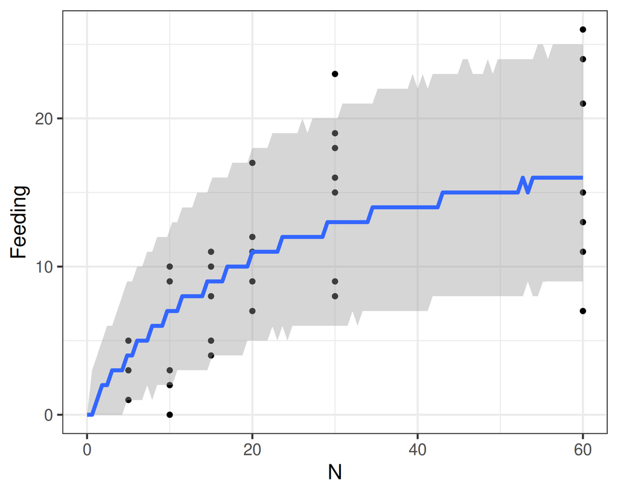

```r
plot(conditional_effects(fit.2,
                         method="posterior_predict"),
     points=TRUE)
```

- Prediction intervals det. & stoch. part  
  $\text{Poisson}(\mu(N))$

## Nonlinear model

```r
formula = bf(Feeding ~ fmax*N/(nhalf+N),
             fmax ~ 1,
             nhalf ~ 1,
             nl = TRUE)
priors  = c(
  prior(normal(20,5), nlpar="fmax", lb=0),
  prior(normal(15,5), nlpar="nhalf", lb=0)
)
fit.2   = brm(formula,
              prior = priors,
              family = poisson(link="identity"),
              data = df)

summary(fit.2)
```

```
 Family: poisson
  Links: mu = identity
Formula: Feeding ~ fmax * N/(nhalf + N)
         fmax ~ 1
         nhalf ~ 1
   Data: df (Number of observations: 32)
  Draws: 4 chains, each with iter = 2000; warmup = 1000; thin = 1;
         total post-warmup draws = 4000

Regression Coefficients:
                Estimate Est.Error l-95% CI u-95% CI Rhat Bulk_ESS Tail_ESS
fmax_Intercept     22.21      1.89    18.60    26.03 1.00     1049     1121
nhalf_Intercept    21.74      3.52    15.11    28.71 1.00     1065     1035

Draws were sampled using sample(hmc). For each parameter, Bulk_ESS
and Tail_ESS are effective sample size measures, and Rhat is the potential
scale reduction factor on split chains (at convergence, Rhat = 1).
```

#### Check model fit

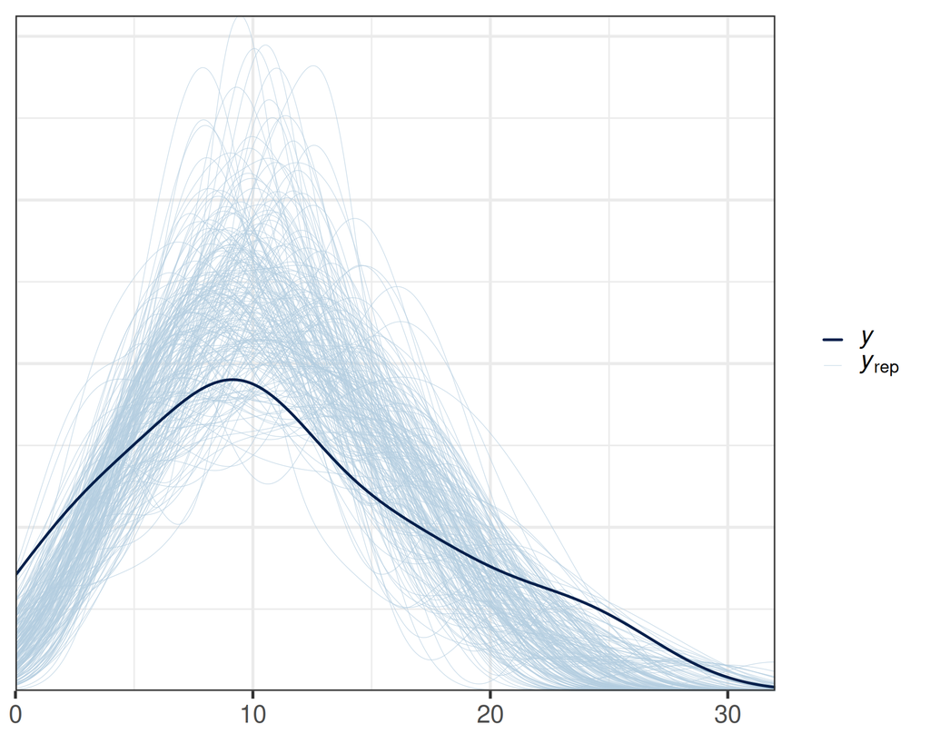

```r
pp_check(fit.2, ndraws=200)
```

- Compare observed vs. predicted data

## Nonlinear model

#### Summary

`brms` workflow similar for  
linear / generalized / nonlinear models:

1. Define statistical model
   - Deterministic part: **nonlinear function**
   - Stochastic part: distribution
   - Priors
2. Run model
3. Check MCMC convergence
4. Check model fit

[figure not shown]

https://www.magnific.com/de/autor/studiogstock

1. Statistical modeling & Bayesian inference
2. Fitting nonlinear curves with `brms`
3. **Continuous & categorical treatment variables**
4. Exercises

## Categorical variable

**Hypothesis:** Predator size affects feeding rates.

Predator size is factor: small / medium / large

```r
library(BayesFR) # contains dataset
data(df_Cuthbert_et_al_2020_ECOL_EVOL)
df = subset(df_Cuthbert_et_al_2020_ECOL_EVOL,
            Predator=="Lepomis macrochirus")
str(df)
```

```
'data.frame':   192 obs. of  7 variables:
 $ N0      : num  2 2 2 4 4 4 8 8 8 16 ...
 $ NE      : num  2 1 2 4 3 4 2 8 5 16 ...
 $ Time    : num  1 1 1 1 1 1 1 1 1 1 ...
 $ Predator: Factor w/ 2 levels "Lepomis macrochirus",..: 1 1 1 1 1 1 1 1 1 1 ...
 $ Prey    : Factor w/ 1 level "Oreochromis mossambicus": 1 1 1 1 1 1 1 1 1 1 ...
 $ PredSize: Factor w/ 3 levels "small","medium",..: 2 2 2 2 2 2 2 2 2 2 ...
 $ PreySize: Factor w/ 3 levels "small","medium",..: 1 1 1 1 1 1 1 1 1 1 ...
```

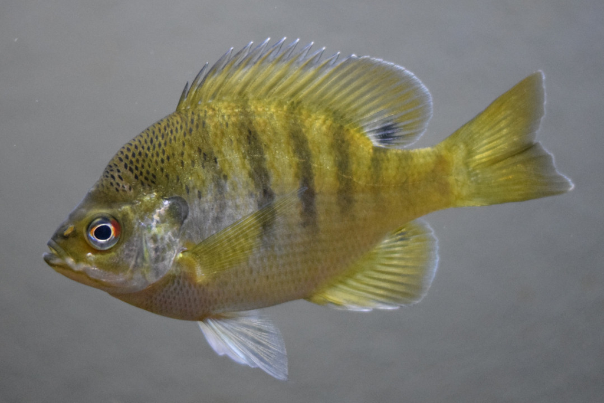

Source: https://commons.wikimedia.org/wiki/File:Bluegill_(fish).jpg CC BY-SA 4.0

## Categorical variable

**Hypothesis:** Predator size affects feeding rates.

Predator size is factor: small / medium / large

```r
library(BayesFR) # contains dataset
data(df_Cuthbert_et_al_2020_ECOL_EVOL)
df = subset(df_Cuthbert_et_al_2020_ECOL_EVOL,
            Predator=="Lepomis macrochirus")
str(df)
```

```
'data.frame':   192 obs. of  7 variables:
 $ N0      : num  2 2 2 4 4 4 8 8 8 16 ...
 $ NE      : num  2 1 2 4 3 4 2 8 5 16 ...
 $ Time    : num  1 1 1 1 1 1 1 1 1 1 ...
 $ Predator: Factor w/ 2 levels "Lepomis macrochirus",..: 1 1 1 1 1 1 1 1 1 1 ...
 $ Prey    : Factor w/ 1 level "Oreochromis mossambicus": 1 1 1 1 1 1 1 1 1 1 ...
 $ PredSize: Factor w/ 3 levels "small","medium",..: 2 2 2 2 2 2 2 2 2 2 ...
 $ PreySize: Factor w/ 3 levels "small","medium",..: 1 1 1 1 1 1 1 1 1 1 ...
```

## Categorical variable

#### Deterministic part: model formula

$\text{Feeding} = \frac{\textcolor{#d62728}{\boldsymbol{F_\max}}\cdot N}{\textcolor{#d62728}{\boldsymbol{N_\text{\bf half}}}+N}$

$F_\max=F_\max(\operatorname{PredSize})$

$N_\operatorname{half}=N_\operatorname{half}(\operatorname{PredSize})$

```r
formula = bf(Feeding ~ fmax*N/(nhalf+N),
             fmax  ~ 0+PredSize,
             nhalf ~ 0+PredSize,
             nl = TRUE)
```

- Make parameters dependent on predictor(s)
- Use classic `lm`-notation
- `0+PredSize` prevents dummy-coding: parameters are $F_\max(\operatorname{small}), F_\max(\operatorname{medium}), F_\max(\operatorname{large})$

## Categorical variable

#### Priors

$F_\max(\operatorname{small}), F_\max(\operatorname{medium}), F_\max(\operatorname{large})$

$N_\operatorname{half}(\operatorname{small}), N_\operatorname{half}(\operatorname{medium}), N_\operatorname{half}(\operatorname{large})$

```r
priors = c(
  prior(normal(20,10), nlpar="fmax", lb=0),
  prior(normal(15,10), nlpar="nhalf", lb=0)
)
```

- Identical priors across all levels of $\operatorname{PredSize}$
- Wide sdevs, weakly informative priors

## Categorical variable

```r
fit.1 = brm(formula,
            prior = priors,
            family = poisson(link="identity"),
            data = df)

summary(fit.1)
```

```
 Family: poisson
  Links: mu = identity
Formula: Feeding ~ fmax * N/(nhalf + N)
         fmax ~ 0 + PredSize
         nhalf ~ 0 + PredSize
   Data: df (Number of observations: 192)
  Draws: 4 chains, each with iter = 2000; warmup = 1000; thin = 1;
         total post-warmup draws = 4000

Regression Coefficients:
                     Estimate Est.Error l-95% CI u-95% CI Rhat Bulk_ESS Tail_ESS
fmax_PredSizesmall       5.65      1.19     3.65     8.33 1.00     2112     2310
fmax_PredSizemedium     16.25      2.28    12.14    21.10 1.00     2272     2222
fmax_PredSizelarge      34.08      3.57    27.47    41.43 1.00     2332     2388
nhalf_PredSizesmall     17.08      6.18     7.26    31.37 1.00     2194     2052
nhalf_PredSizemedium    31.08      6.50    19.61    44.67 1.00     2198     1888
nhalf_PredSizelarge     39.88      5.91    29.29    51.72 1.00     2317     2315

Draws were sampled using sample(hmc). For each parameter, Bulk_ESS
and Tail_ESS are effective sample size measures, and Rhat is the potential
scale reduction factor on split chains (at convergence, Rhat = 1).
```

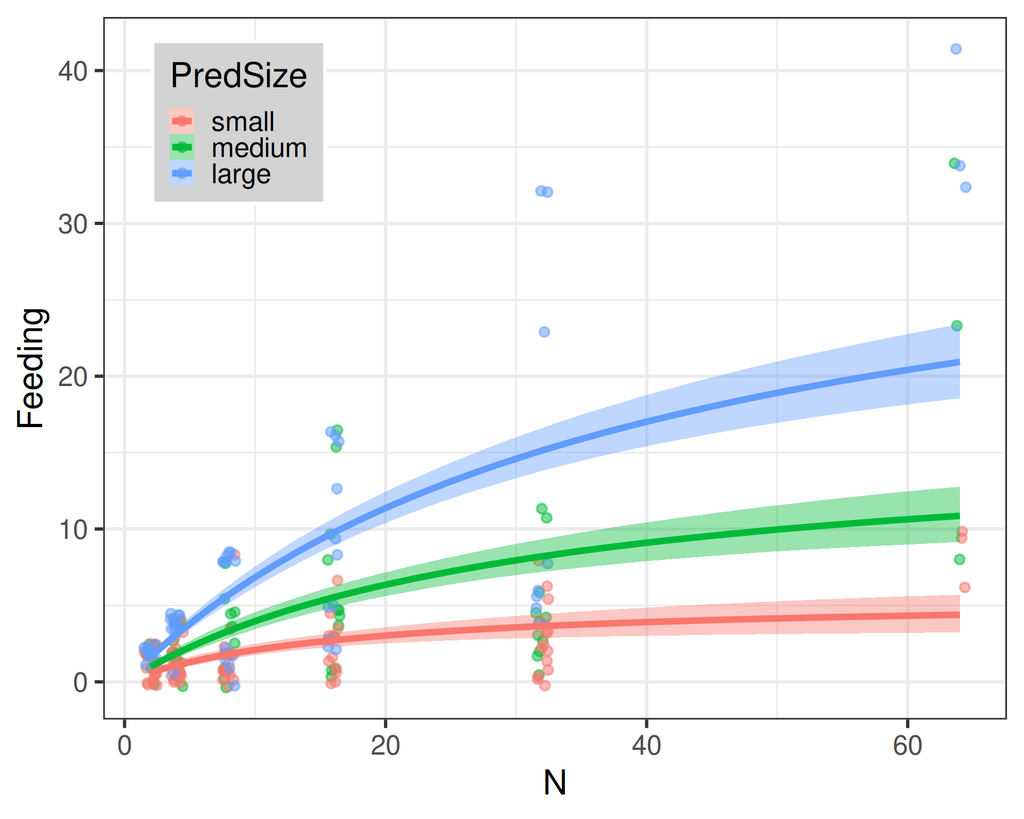

```r
plot(conditional_effects(fit.1,
                         effects="N:PredSize"),
     points = TRUE)
```

## Categorical variable

```r
fit.1 = brm(formula,
            prior = priors,
            family = poisson(link="identity"),
            data = df)

summary(fit.1)
```

```
 Family: poisson
  Links: mu = identity
Formula: Feeding ~ fmax * N/(nhalf + N)
         fmax ~ 0 + PredSize
         nhalf ~ 0 + PredSize
   Data: df (Number of observations: 192)
  Draws: 4 chains, each with iter = 2000; warmup = 1000; thin = 1;
         total post-warmup draws = 4000

Regression Coefficients:
                     Estimate Est.Error l-95% CI u-95% CI Rhat Bulk_ESS Tail_ESS
fmax_PredSizesmall       5.65      1.19     3.65     8.33 1.00     2112     2310
fmax_PredSizemedium     16.25      2.28    12.14    21.10 1.00     2272     2222
fmax_PredSizelarge      34.08      3.57    27.47    41.43 1.00     2332     2388
nhalf_PredSizesmall     17.08      6.18     7.26    31.37 1.00     2194     2052
nhalf_PredSizemedium    31.08      6.50    19.61    44.67 1.00     2198     1888
nhalf_PredSizelarge     39.88      5.91    29.29    51.72 1.00     2317     2315

Draws were sampled using sample(hmc). For each parameter, Bulk_ESS
and Tail_ESS are effective sample size measures, and Rhat is the potential
scale reduction factor on split chains (at convergence, Rhat = 1).
```

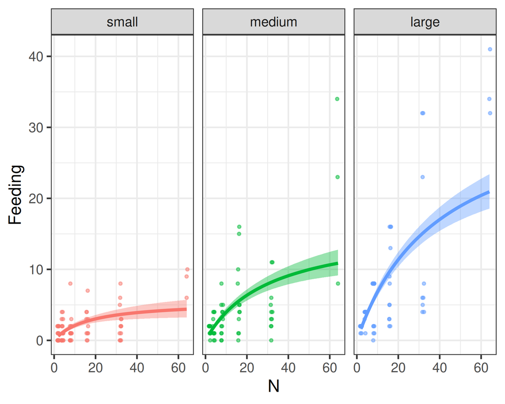

```r
p = plot(conditional_effects(fit.1,
                             effects="N:PredSize"),
         points = TRUE, plot = FALSE)
p[[1]] + facet_wrap(~PredSize)
```

## Categorical variable

#### Means and contrasts

```r
library(emmeans)
em_fmax = emmeans(fit.1, ~ PredSize, nlpar = "fmax")
em_fmax
```

```
 PredSize emmean lower.HPD upper.HPD
 small      5.51       3.4      7.95
 medium    16.08      12.0     20.86
 large     33.98      27.2     41.01

Point estimate displayed: median
HPD interval probability: 0.95
```

Here: same as fitted parameters

```r
pairs(em_fmax)
```

```
 contrast       estimate lower.HPD upper.HPD
 small - medium    -10.5     -15.6     -5.66
 small - large     -28.3     -35.6    -21.15
 medium - large    -17.8     -26.1     -9.67

Point estimate displayed: median
HPD interval probability: 0.95
```

Uses full posterior distribution to compute differences

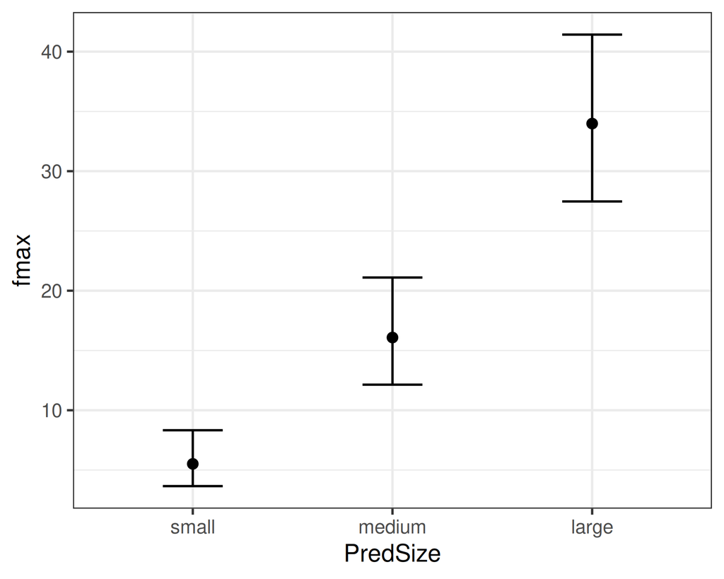

```r
plot(conditional_effects(fit.1,
                         effects="PredSize",
                         nlpar="fmax"))
```

## Categorical variable

#### Means and contrasts

```r
library(emmeans)
em_nhalf = emmeans(fit.1, ~ PredSize, nlpar = "nhalf")
em_nhalf
```

```
 PredSize emmean lower.HPD upper.HPD
 small      16.3      6.67      29.9
 medium     30.7     19.57      44.6
 large      39.7     29.41      51.8

Point estimate displayed: median
HPD interval probability: 0.95
```

Here: same as fitted parameters

```r
pairs(em_nhalf)
```

```
 contrast       estimate lower.HPD upper.HPD
 small - medium   -14.04     -30.9      4.79
 small - large    -22.89     -39.2     -6.06
 medium - large    -8.98     -24.5      9.92

Point estimate displayed: median
HPD interval probability: 0.95
```

Uses full posterior distribution to compute differences

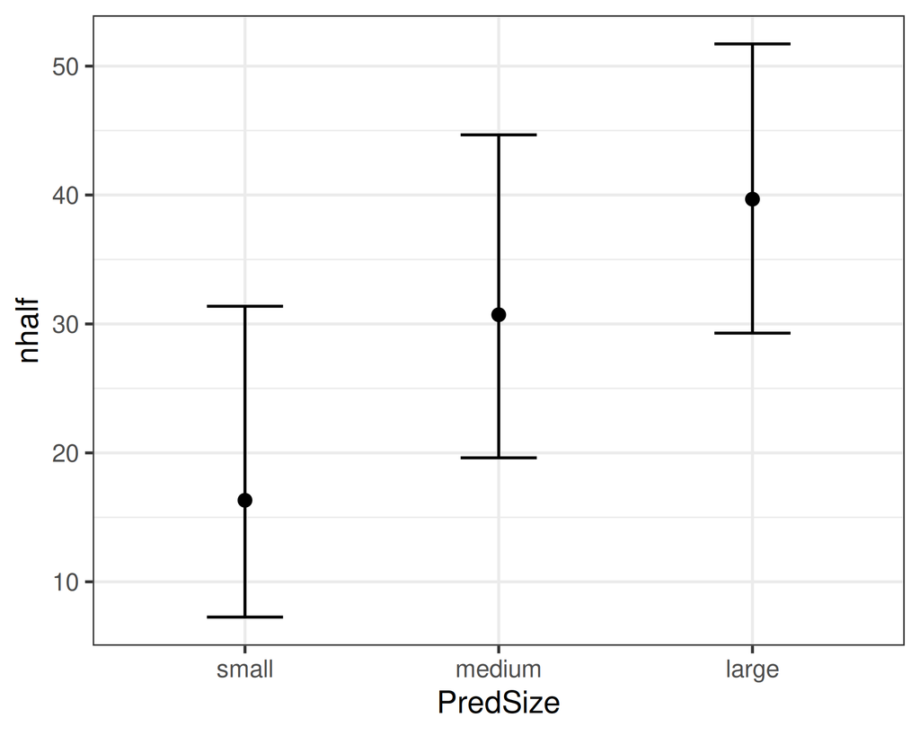

```r
plot(conditional_effects(fit.1,
                         effects="PredSize",
                         nlpar="nhalf"))
```

## Categorical variable

#### Hypothesis testing

```r
hypothesis(fit.1,
           "nhalf_PredSizelarge > nhalf_PredSizemedium")
```

```
Hypothesis Tests for class b:
                Hypothesis Estimate Est.Error CI.Lower CI.Upper Evid.Ratio Post.Prob Star
1 (nhalf_PredSizela... > 0     8.81      8.81    -5.87    22.78       5.32      0.84
---
'CI': 90%-CI for one-sided and 95%-CI for two-sided hypotheses.
'*': For one-sided hypotheses, the posterior probability exceeds 95%;
for two-sided hypotheses, the value tested against lies outside the 95%-CI.
Posterior probabilities of point hypotheses assume equal prior probabilities.
```

Posterior probability:

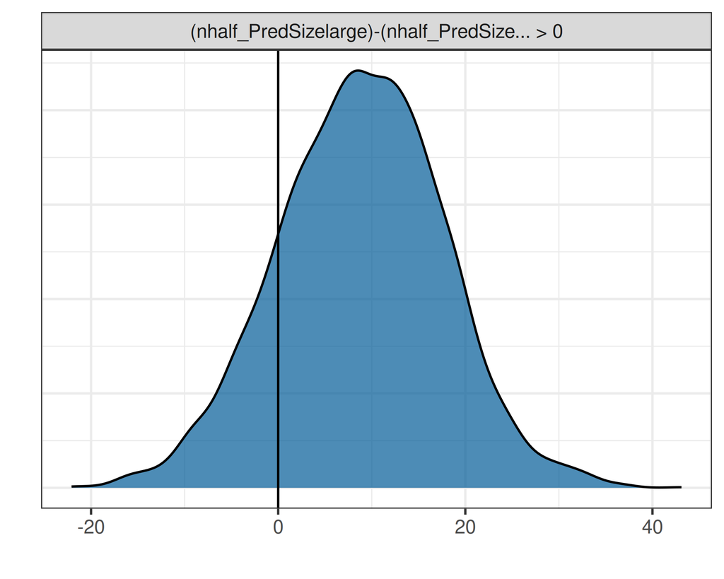

```r
p = plot(
  hypothesis(fit.1,
             "nhalf_PredSizelarge > nhalf_PredSizemedium"),
  plot = FALSE
)
p[[1]] + geom_vline(xintercept=0)
```

## Categorical variable

#### Model comparison

```r
formula = bf(Feeding ~ fmax*N/(nhalf+N),
             fmax  ~ 1,
             nhalf ~ 1,
             nl = TRUE)
priors = c(
  prior(normal(20,10), nlpar="fmax", lb=0),
  prior(normal(15,10), nlpar="nhalf", lb=0)
)
fit.0 = brm(formula,
            prior = priors,
            family = poisson(link="identity"),
            data = df)
```

- Define “null” model: remove predictor $\text{PredSize}$
- Test full model `fit.1` against null model `fit.0`
- Similar to ANOVA in linear models

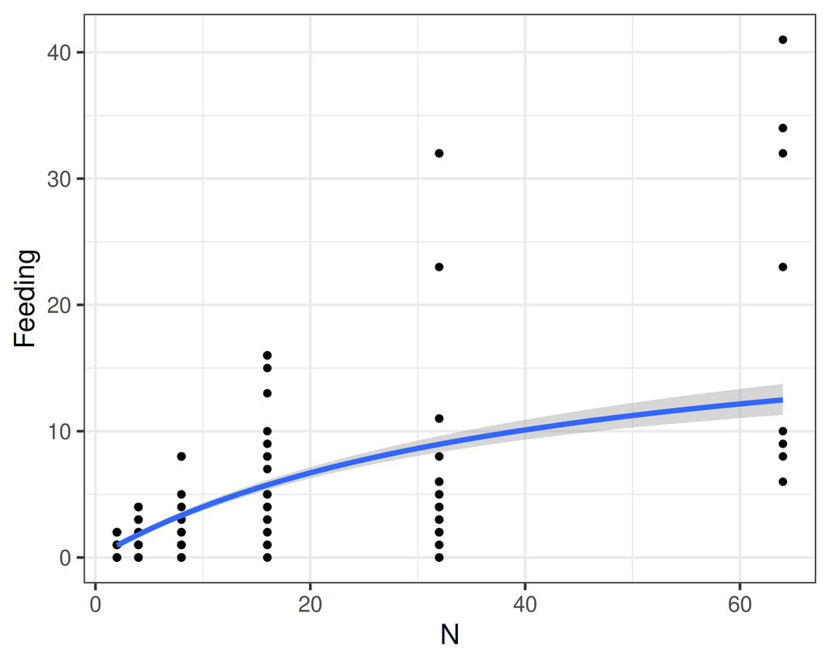

```r
plot(conditional_effects(fit.0,
                         effects="N"),
     points = TRUE)
```

## Categorical variable

#### Model comparison

```r
formula = bf(Feeding ~ fmax*N/(nhalf+N),
             fmax  ~ 1,
             nhalf ~ 1,
             nl = TRUE)
priors = c(
  prior(normal(20,10), nlpar="fmax", lb=0),
  prior(normal(15,10), nlpar="nhalf", lb=0)
)
fit.0 = brm(formula,
            prior = priors,
            family = poisson(link="identity"),
            data = df)
```

- Define “null” model: remove predictor $\text{PredSize}$
- Test full model `fit.1` against null model `fit.0`
- Similar to ANOVA in linear models

```r
LOO(fit.0, fit.1)
```

```
 model elpd_diff se_diff p_worse diag_diff diag_elpd
 fit.1       0.0     0.0      NA
 fit.0    -107.5    32.6    1.00
```

- **L**eave-**O**ne-**O**ut cross validation
- Information criterion similar to AIC
- Ranks models by predictive accuracy `elpd`

**→ `fit.1` performs better than `fit.0`**  
**→ Yes, feeding rates are affected by predator size.**

## Categorical variable

#### Summary

- Define parameters depending on predictor according to research questions  
  E.g. not all parameters required to vary with predictor
- `par ~ factorA` puts linear model inside your nonlinear model
- `par ~ 0 + factorA` prevents dummy-coding, if just 1 factor
- Classical linear syntax for multiple factors  
  `par ~ factorA + factorB`  
  `par ~ factorA * factorB`
- Test full model against a null model `par ~ 1` using `LOO()`
- Individual contrasts between factor levels with `emmeans()` or `hypothesis()`
1. Statistical modeling & Bayesian inference
2. Fitting nonlinear curves with `brms`
3. **Continuous & categorical treatment variables**
4. Exercises

## Continuous variable

**Hypothesis:** Predator size affects feeding rates.

Predator size (head width) is numerical

```r
library(BayesFR) # contains dataset
data(df_Davidson_et_al_2021_FUN_ECOL)
df = subset(df_Davidson_et_al_2021_FUN_ECOL,
            Predator=="Erythemis simplicicollis")
str(df)
```

```
'data.frame':   46 obs. of  7 variables:
 $ N0         : int  40 10 40 10 80 40 80 80 40 10 ...
 $ NE         : int  38 10 18 10 70 39 41 43 32 10 ...
 $ Time       : num  24 24 24 24 24 24 24 24 24 24 ...
 $ Predator   : Factor w/ 2 levels "Erythemis simplicicollis",..: 1 1 1 1 1 1 1 1 1 1 ...
 $ Prey       : Factor w/ 1 level "Aedes atropalpus": 1 1 1 1 1 1 1 1 1 1 ...
 $ Temperature: int  24 20 24 28 28 28 36 28 32 36 ...
 $ HeadWidth  : num  5 3.9 3.2 2.7 5.1 5 3.2 3.9 4 4.2 ...
```

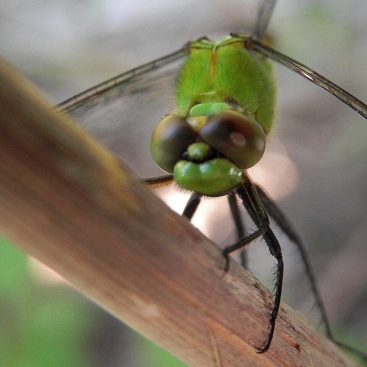

Source: https://commons.wikimedia.org/wiki/File:Eastern_Pondhawk_(Erythemis_simplicicollis),_Female_03.jpg  
CC BY-SA 4.0

## Continuous variable

**Hypothesis:** Predator size affects feeding rates.

Predator size (head width) is numerical

```r
library(BayesFR) # contains dataset
data(df_Davidson_et_al_2021_FUN_ECOL)
df = subset(df_Davidson_et_al_2021_FUN_ECOL,
            Predator=="Erythemis simplicicollis")
str(df)
```

```
'data.frame':   46 obs. of  7 variables:
 $ N0         : int  40 10 40 10 80 40 80 80 40 10 ...
 $ NE         : int  38 10 18 10 70 39 41 43 32 10 ...
 $ Time       : num  24 24 24 24 24 24 24 24 24 24 ...
 $ Predator   : Factor w/ 2 levels "Erythemis simplicicollis",..: 1 1 1 1 1 1 1 1 1 1 ...
 $ Prey       : Factor w/ 1 level "Aedes atropalpus": 1 1 1 1 1 1 1 1 1 1 ...
 $ Temperature: int  24 20 24 28 28 28 36 28 32 36 ...
 $ HeadWidth  : num  5 3.9 3.2 2.7 5.1 5 3.2 3.9 4 4.2 ...
```

## Continuous variable

#### Deterministic part: model formula

$\text{Feeding} = \frac{\textcolor{var(--highlight-high-border)}{\boldsymbol{F_\max}}\cdot N}{\textcolor{var(--highlight-high-border)}{\boldsymbol{N_\text{\bf half}}}+N}$

$F_\max=\beta_{0}+\beta_{1}\cdot\text{HeadWidth}$

$N_\operatorname{half}$

```r
formula = bf(Feeding ~ fmax*N/(nhalf+N),
             fmax  ~ scale(HeadWidth),
             nhalf ~ 1,
             nl = TRUE)
```

- Make parameters dependent on predictor(s)
- Use classic `lm`-notation
- `scale()` the predictor to `mean=0`, `sd=1`  
  can make pars more interpretable:  
  intercept $\beta_{0}=F_\max$ for avg. $\text{HeadWidth}$

## Continuous variable

#### Priors

$F_\max={\boldsymbol{\textcolor{var(--highlight-high-border)}{\beta_{0}}}}+{\boldsymbol{\textcolor{var(--highlight-high-border)}{\beta_{1}}}}\cdot\text{HeadWidth}$

${\boldsymbol{\textcolor{var(--highlight-high-border)}{{N_\operatorname{half}}}}}$

```r
default_prior(formula,
              family = poisson(link="identity"),
              data = df
)
```

```
  prior class           coef group resp dpar nlpar lb ub tag       source
 (flat)     b                                 fmax                default
 (flat)     b      Intercept                  fmax           (vectorized)
 (flat)     b scaleHeadWidth                  fmax           (vectorized)
 (flat)     b                                nhalf                default
 (flat)     b      Intercept                 nhalf           (vectorized)
```

- First, check parameters structure and names

## Continuous variable

#### Priors

$F_\max={\boldsymbol{\textcolor{var(--highlight-high-border)}{\beta_{0}}}}+{\boldsymbol{\textcolor{var(--highlight-high-border)}{\beta_{1}}}}\cdot\text{HeadWidth}$

${\boldsymbol{\textcolor{var(--highlight-high-border)}{{N_\operatorname{half}}}}}$

```r
priors = c(
  prior(normal(40,20), nlpar="fmax", coef="Intercept"),
  prior(normal(0 ,10), nlpar="fmax", coef="scaleHeadWidth"),
  prior(normal(30,20), nlpar="nhalf", lb=0)
)
```

- Weakly informative priors for intercept and slope of $F_\max$

## Continuous variable

```r
fit.1 = brm(formula,
            prior = priors,
            family = poisson(link="identity"),
            data = df)

summary(fit.1)
```

```
 Family: poisson
  Links: mu = identity
Formula: Feeding ~ fmax * N/(nhalf + N)
         fmax ~ scale(HeadWidth)
         nhalf ~ 1
   Data: df (Number of observations: 46)
  Draws: 4 chains, each with iter = 2000; warmup = 1000; thin = 1;
         total post-warmup draws = 4000

Regression Coefficients:
                    Estimate Est.Error l-95% CI u-95% CI Rhat Bulk_ESS Tail_ESS
fmax_Intercept         62.85      5.36    53.45    74.11 1.00     1435     1748
fmax_scaleHeadWidth    10.40      1.83     6.98    14.14 1.00     1801     1716
nhalf_Intercept        47.92      7.73    34.39    64.04 1.00     1450     1798

Draws were sampled using sample(hmc). For each parameter, Bulk_ESS
and Tail_ESS are effective sample size measures, and Rhat is the potential
scale reduction factor on split chains (at convergence, Rhat = 1).
```

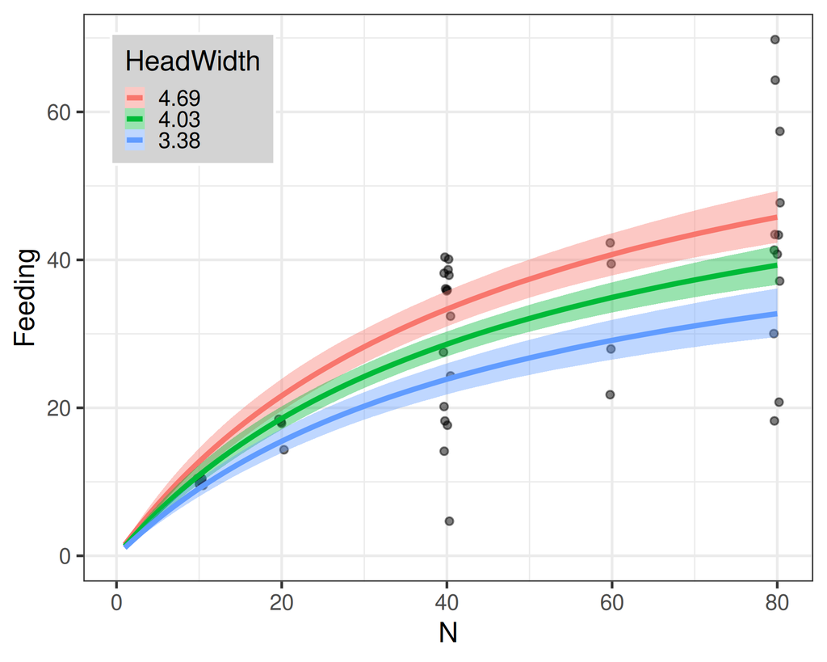

```r
plot(conditional_effects(fit.1,
                         effects="N:HeadWidth"),
     points = TRUE)
```

- Automatically uses 3 levels for the predictor: $\mu,~~\mu+1\sigma,~~\mu-1\sigma$

## Continuous variable

#### Trends

```r
fixef(fit.1)
```

```
                    Estimate Est.Error      Q2.5    Q97.5
fmax_Intercept      62.85239  5.360279 53.453940 74.11208
fmax_scaleHeadWidth 10.39928  1.834952  6.981584 14.14373
nhalf_Intercept     47.91796  7.727842 34.393725 64.04247
```

$F_\max$ increases by $\beta_1=10.40$ per $1\sigma$ increase in size

scale back to original scale

```r
fixef(fit.1)["fmax_scaleHeadWidth", "Estimate"] / sd(df$HeadWidth)
```

```
[1] 15.86927
```

or just use `emmeans`

```r
library(emmeans)
em_trend = emtrends(fit.1, var="HeadWidth", nlpar="fmax")
print(em_trend)
```

```
 HeadWidth HeadWidth.trend lower.HPD upper.HPD
      4.03            15.7      10.6      21.5

Point estimate displayed: median
HPD interval probability: 0.95
```

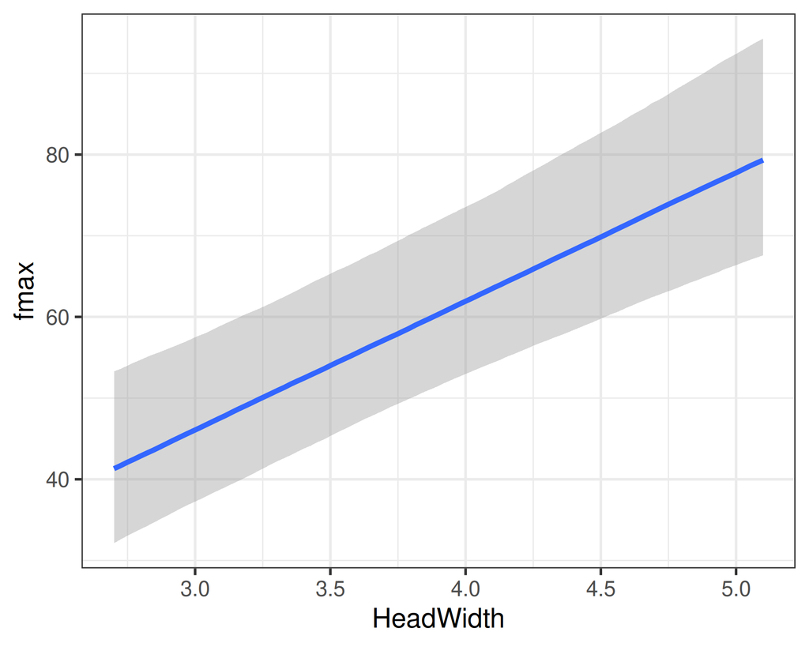

```r
plot(conditional_effects(fit.1,
                         effects="HeadWidth",
                         nlpar="fmax"))
```

## Continuous variable

#### Hypothesis testing

```r
hypothesis(fit.1,
           "fmax_scaleHeadWidth > 0")
```

```
Hypothesis Tests for class b:
                Hypothesis Estimate Est.Error CI.Lower CI.Upper Evid.Ratio Post.Prob Star
1 (fmax_scaleHeadWi... > 0     10.4      1.83     7.51    13.56        Inf         1    *
---
'CI': 90%-CI for one-sided and 95%-CI for two-sided hypotheses.
'*': For one-sided hypotheses, the posterior probability exceeds 95%;
for two-sided hypotheses, the value tested against lies outside the 95%-CI.
Posterior probabilities of point hypotheses assume equal prior probabilities.
```

Posterior probability:

$P(\beta_1>0)=1.00$

**→ Yes, feeding rates are positively affected by predator size.**

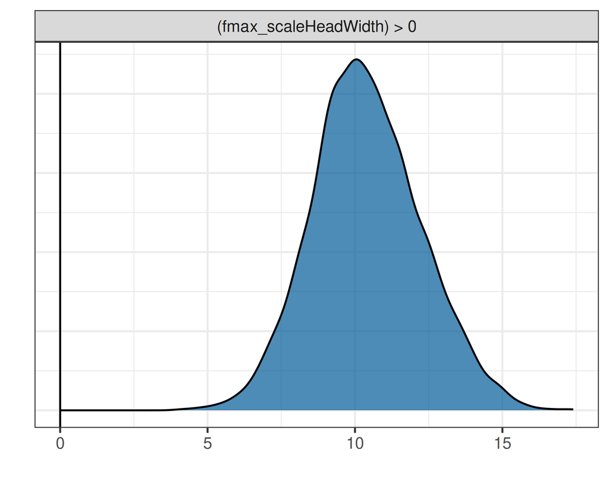

```r
p = plot(
  hypothesis(fit.1,
             "fmax_scaleHeadWidth > 0"),
  plot = FALSE
)
p[[1]] + geom_vline(xintercept=0)
```

## Continuous variable with link

#### Deterministic part: positive parameters

$\text{Feeding} = \frac{\textcolor{black}{{F_\max}}\cdot N}{\textcolor{black}{{N_\text{half}}}+N}$

$$\begin{align}
F_\max&=\textcolor{var(--highlight-high-border)}{\boldsymbol{\exp}}\left( \beta_{0}+\beta_{1}\cdot\text{HeadWidth}\right)\textcolor{var(--highlight-high-border)}{\boldsymbol{\ >0}}\\
\Leftrightarrow \textcolor{var(--highlight-high-border)}{\boldsymbol{\log}}\left( F_\max\right)& =\beta_{0}+\beta_{1}\cdot\text{HeadWidth}
\end{align}$$

```r
formula = bf(Feeding ~ fmax*N/(nhalf+N),
             nlf(fmax ~ exp(fmaxlog)),   # exp(b0+b1*x)
             fmaxlog ~ scale(HeadWidth), # b0+b1*x
             nhalf ~ 1,
             nl = TRUE)
```

- Define new parameter `fmaxlog` with its linear model
- Transform to `fmax~exp(fmaxlog)`

## Continuous variable with link

#### Priors

$$\begin{align}
F_\max&=\exp\left( \beta_{0}+\beta_{1}\cdot\text{HeadWidth}\right)\\
\Leftrightarrow \log\left( F_\max\right)& =\textcolor{var(--highlight-high-border)}{\boldsymbol{\beta_{0}}}+\textcolor{var(--highlight-high-border)}{\boldsymbol{\beta_{1}}}\cdot\text{HeadWidth}
\end{align}$$

```r
priors = c(
  prior(normal(log(40),1), nlpar="fmaxlog", coef="Intercept"),
  prior(normal(0,1),       nlpar="fmaxlog", coef="scaleHeadWidth"),
  prior(normal(30,20), nlpar="nhalf", lb=0)
)
```

- Priors for intercept and slope of `fmaxlog`,  
  which is on logscale

## Continuous variable with link

```r
fit.2 = brm(formula,
            prior = priors,
            family = poisson(link="identity"),
            data = df)

summary(fit.2)
```

```
 Family: poisson
  Links: mu = identity
Formula: Feeding ~ fmax * N/(nhalf + N)
         fmax ~ exp(fmaxlog)
         fmaxlog ~ scale(HeadWidth)
         nhalf ~ 1
   Data: df (Number of observations: 46)
  Draws: 4 chains, each with iter = 2000; warmup = 1000; thin = 1;
         total post-warmup draws = 4000

Regression Coefficients:
                       Estimate Est.Error l-95% CI u-95% CI Rhat Bulk_ESS Tail_ESS
fmaxlog_Intercept          4.13      0.10     3.94     4.33 1.00     1215     1477
fmaxlog_scaleHeadWidth     0.18      0.03     0.12     0.23 1.00     1862     1827
nhalf_Intercept           48.71      8.79    33.58    68.46 1.00     1203     1247

Draws were sampled using sample(hmc). For each parameter, Bulk_ESS
and Tail_ESS are effective sample size measures, and Rhat is the potential
scale reduction factor on split chains (at convergence, Rhat = 1).
```

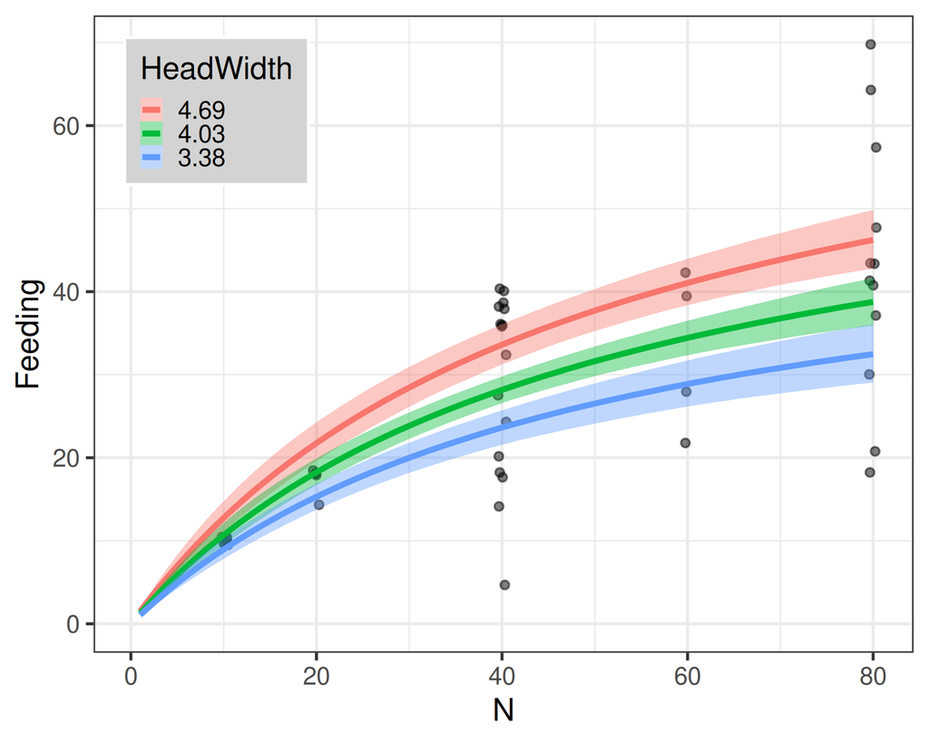

```r
plot(conditional_effects(fit.2,
                         effects="N:HeadWidth"),
     points = TRUE)
```

- Automatically uses 3 levels for the predictor: $\mu,~~\mu+1\sigma,~~\mu-1\sigma$

## Continuous variable with link

#### Trends

```r
library(emmeans)
em_trend = emtrends(fit.2, var="HeadWidth", nlpar="fmaxlog")
print(em_trend)
```

```
 HeadWidth HeadWidth.trend lower.HPD upper.HPD
      4.03            0.27     0.186     0.358

Point estimate displayed: median
HPD interval probability: 0.95
```

- $\log(F_\max)$ increases by $+0.27$ per $1$ unit of size (*additive*)
- $F_\max$ increases by $\times\exp(0.27)=1.31$ per $1$ unit of size (*multiplicative*)
- That’s $31\%$ increase per $1$ unit of size

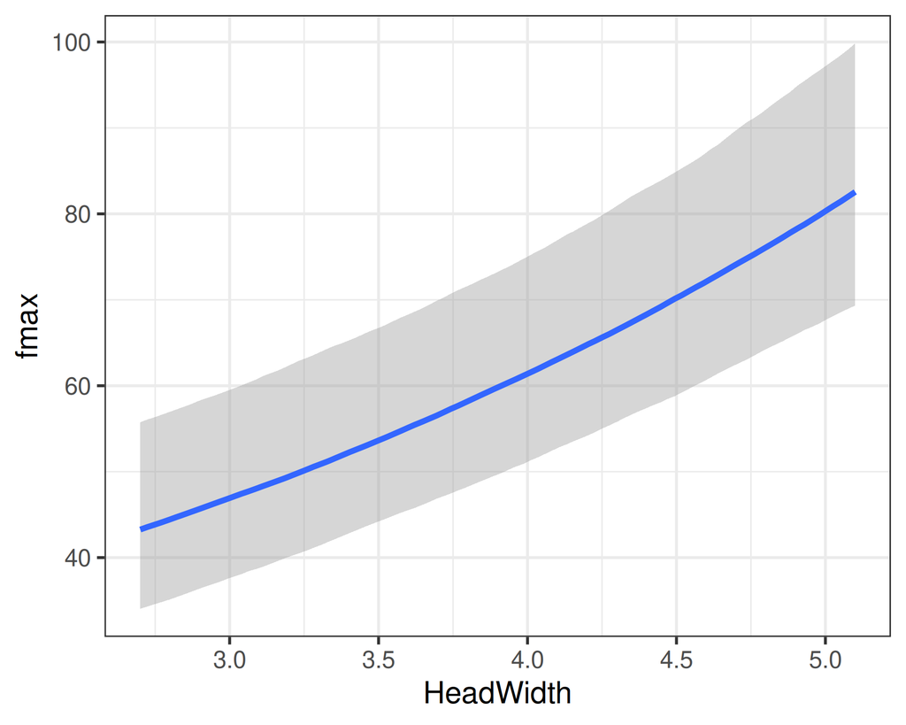

```r
plot(conditional_effects(fit.2,
                         effects="HeadWidth",
                         nlpar="fmax"))
```

## Continuous variable

#### Summary

- Put a linear model `par ~ varA` inside your nonlinear model
- Test effects with `hypothesis()`
- `scale(varA)` can ease prior specification  
  back-transform slopes with `emtrends()`
- Parameter bounds cannot be guaranteed via priors
- Define linear models on unrestricted scale, manually transform to restricted scale
- log-link for $0<\text{par}$: `parlog~varA, nlf(par~exp(parlog)`
- logit-link for $0<\text{par}<1$: `parlogit~varA, nlf(par~1/(1+exp(-parlogit))`

## … and more!

- Mix factorial and numerical treatments variables  
  `par ~ factorA + varB`  
  `par ~ factorA * varB`
- Random effects  
  `par ~ (1|group)`
- Parameter itself has nonlinear relationship with other variable?  
  Use a GAM!  
  `par ~ s(var)`
- Prediction model too complex to just write in `bf(y~...)` ?  
  Write separate `Stan`-function which is used in `brms` !  
  `brm(..., stanvars = )`
1. Statistical modeling & Bayesian inference
2. Fitting nonlinear curves with `brms`
3. Continuous & categorical treatment variables
4. **Exercises**

## 1) Individual growth (basic)

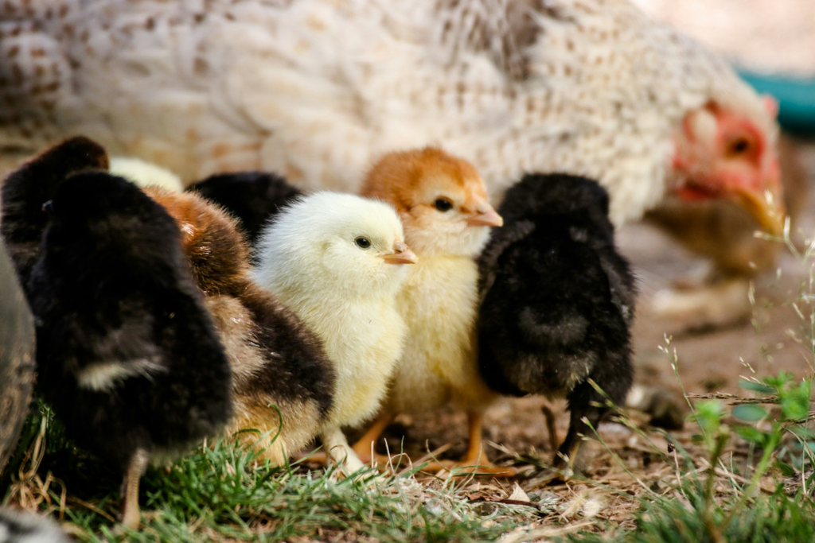

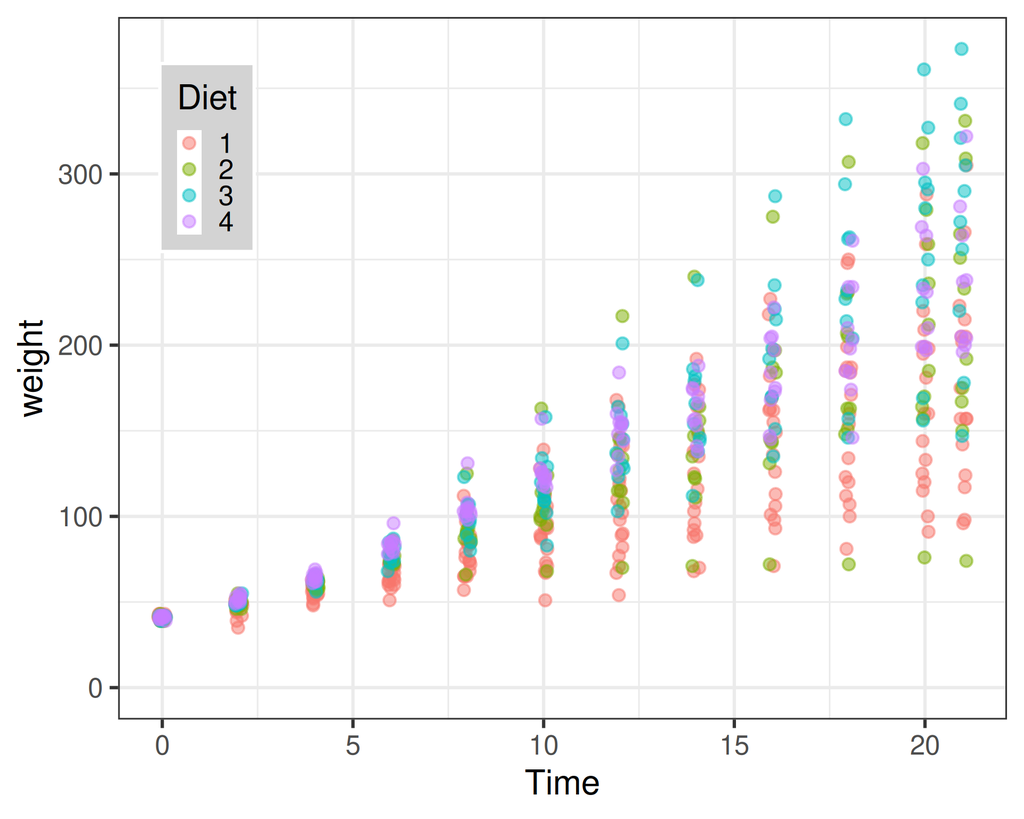

```r
df = ChickWeight
ggplot(df, aes(x=Time, y=weight, col=Diet)) +
  geom_jitter(alpha=0.5, width=0.1, height=0)
```

## 1) Individual growth (basic)

#### Logistic growth model

$$\text{weight}(t) \sim \frac{w_\max}{1+\left( \frac{w_\max}{w_0}-1\right) e^{-r\cdot t} }$$

$w_\max~$ maximum weight

$w_0~~~~~$ initial weight

$r~~~~~~~$ maximum growth rate

Richards model family includes various individual weight growths model, defined by an exponent $d$: Logistic ($2$), Bertalanffy ($1.5$), Gompertz ($1$), …

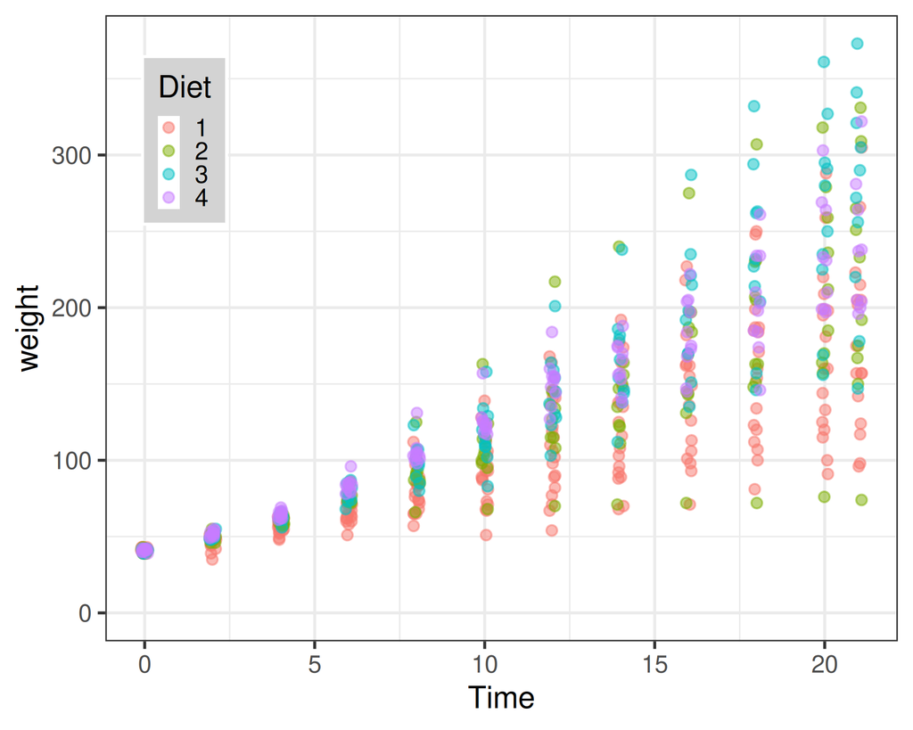

```r
df = ChickWeight
ggplot(df, aes(x=Time, y=weight, col=Diet)) +
  geom_jitter(alpha=0.5, width=0.1, height=0)
```

## 1) Individual growth (basic)

#### Exercises

- Model logistic growth function  
  *Note: Choose appropriate distribution*
- Test the effect of factor `Diet` on growth.  
  Which parameters should depend on `Diet` ?
- Dataset is collection of individual growth timeseries.  
  Model `(1|Chick)` as random effect.  
  Which parameters should depend on `Chick` ?  
  *Note: might have to enforce positive parameters.*

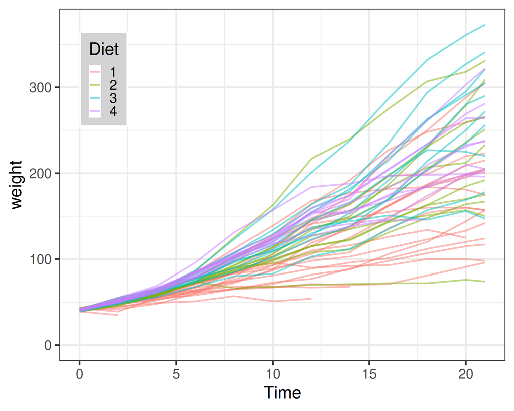

```r
df = ChickWeight
ggplot(df, aes(x=Time, y=weight, col=Diet, group=Chick)) +
  geom_line(alpha=0.5)
```

## 2) Thermal performance (advanced)

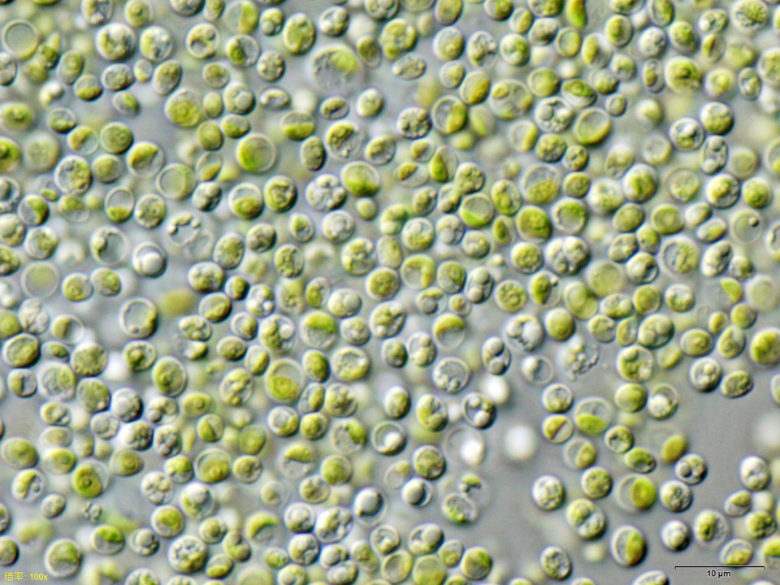

Source: https://commons.wikimedia.org/wiki/File:Chlorella_vulgaris_NIES2170.jpg CC BY-SA 3.0

```r
library("rTPC")
df = chlorella_tpc
df = subset(df, process=="adaptation" & flux=="photosynthesis")
ggplot(df, aes(x=temp, y=rate, col=growth_temp)) +
  geom_jitter(alpha=0.5, width=0.2, height=0)
```

[output not shown]

## 2) Thermal performance (advanced)

#### Sharpe-Schoolfield model

$$\text{rate}(T) \sim r_0 \frac{\exp \left(-\frac{E_a}{k}\left(\frac{1}{T}-\frac{1}{T_0} \right) \right)}{1+\exp \left(\frac{E_h}{k}\left(\frac{1}{T_h}-\frac{1}{T} \right) \right)}$$
$k~~~$ Boltzman **constant**

$T_0~$ reference temperature, **constant** [Kelvin]

$r_0~~$ rate at $T_0$

$E_a~$ activation energy [eV]

$E_h~$ deactivation energy [eV]

$T_h~$ location (shortly after peak) [Kelvin]

```r
library("rTPC")
df = chlorella_tpc
df = subset(df, process=="adaptation" & flux=="photosynthesis")
ggplot(df, aes(x=temp, y=rate, col=growth_temp)) +
  geom_jitter(alpha=0.5, width=0.2, height=0)
```

## 2) Thermal performance (advanced)

#### Exercise

- Model photosynthesis rate with Sharpe-Schoolfield  
  *Notes:*  
  *Convert temperature to Kelvin in dataframe*  
  *Supply constants as dataframe columns*  
  *Set meaningful priors*  
  *Might need to provide initial values*

```r
init = list(b_Th=315, ...)
inits = rep(list(init), 4) # for 4 chains
```

```r
library("rTPC")
df = chlorella_tpc
df = subset(df, process=="adaptation" & flux=="photosynthesis")
ggplot(df, aes(x=temp, y=rate, col=growth_temp)) +
  geom_jitter(alpha=0.5, width=0.2, height=0)
```

## 2) Thermal performance (advanced)

#### Exercise

- Test if rate scales with acclimation temperature.  
  `r0 ~ scale(growth_temp)`  
  *Notes:*  
  *Ensure that $r_0$ stays positive*  
  *Look up parameter structure with `default_prior()`*  
  *Priors: $r_0$ now has intercept and slope*

```r
prior = c(prior(normal(0,1), nlpar="logr0", coef="Intercept"),
          prior(normal(0,1), nlpar="logr0", coef="scalegrowth_temp"),
          ...)
```

$~~$ *Inits: both can be supplied in a vector for $r_0$*

```r
init = list(b_logr0=c(0,-0.5), ...)
```

```r
library("rTPC")
df = chlorella_tpc
df = subset(df, process=="adaptation" & flux=="photosynthesis")
ggplot(df, aes(x=temp, y=rate, col=growth_temp)) +
  geom_jitter(alpha=0.5, width=0.2, height=0)
```

## 2) Thermal performance (advanced)

#### Exercise

- Test if temperature optimum changes with acclimation temperature, by making all parameters depend on `growth_temp`

```r
library("rTPC")
df = chlorella_tpc
df = subset(df, process=="adaptation" & flux=="photosynthesis")
ggplot(df, aes(x=temp, y=rate, col=growth_temp)) +
  geom_jitter(alpha=0.5, width=0.2, height=0)
```